# Risk Factor Analysis

## Outcome Variable

**Outcome Variable:** ever_sstunted

## Predictor Variables

**Intervention Variable:** brthmon

**Adjustment Set:**

unadjusted

## Stratifying Variables

The analysis was stratified on these variable(s):

- agecat
- studyid
- country

## Data Summary

| agecat | studyid | country | brthmon | ever_sstunted | n_cell | n | outcome_variable |
| --- | --- | --- | --- | --- | --- | --- | --- |
| 0-24 months | ki0047075b-MAL-ED | BANGLADESH | 1 | 0 | 17 | 265 | ever_sstunted |
| 0-24 months | ki0047075b-MAL-ED | BANGLADESH | 1 | 1 | 4 | 265 | ever_sstunted |
| 0-24 months | ki0047075b-MAL-ED | BANGLADESH | 2 | 0 | 18 | 265 | ever_sstunted |
| 0-24 months | ki0047075b-MAL-ED | BANGLADESH | 2 | 1 | 7 | 265 | ever_sstunted |
| 0-24 months | ki0047075b-MAL-ED | BANGLADESH | 3 | 0 | 19 | 265 | ever_sstunted |
| 0-24 months | ki0047075b-MAL-ED | BANGLADESH | 3 | 1 | 6 | 265 | ever_sstunted |
| 0-24 months | ki0047075b-MAL-ED | BANGLADESH | 4 | 0 | 19 | 265 | ever_sstunted |
| 0-24 months | ki0047075b-MAL-ED | BANGLADESH | 4 | 1 | 3 | 265 | ever_sstunted |
| 0-24 months | ki0047075b-MAL-ED | BANGLADESH | 5 | 0 | 15 | 265 | ever_sstunted |
| 0-24 months | ki0047075b-MAL-ED | BANGLADESH | 5 | 1 | 7 | 265 | ever_sstunted |
| 0-24 months | ki0047075b-MAL-ED | BANGLADESH | 6 | 0 | 10 | 265 | ever_sstunted |
| 0-24 months | ki0047075b-MAL-ED | BANGLADESH | 6 | 1 | 1 | 265 | ever_sstunted |
| 0-24 months | ki0047075b-MAL-ED | BANGLADESH | 7 | 0 | 15 | 265 | ever_sstunted |
| 0-24 months | ki0047075b-MAL-ED | BANGLADESH | 7 | 1 | 5 | 265 | ever_sstunted |
| 0-24 months | ki0047075b-MAL-ED | BANGLADESH | 8 | 0 | 17 | 265 | ever_sstunted |
| 0-24 months | ki0047075b-MAL-ED | BANGLADESH | 8 | 1 | 9 | 265 | ever_sstunted |
| 0-24 months | ki0047075b-MAL-ED | BANGLADESH | 9 | 0 | 18 | 265 | ever_sstunted |
| 0-24 months | ki0047075b-MAL-ED | BANGLADESH | 9 | 1 | 5 | 265 | ever_sstunted |
| 0-24 months | ki0047075b-MAL-ED | BANGLADESH | 10 | 0 | 18 | 265 | ever_sstunted |
| 0-24 months | ki0047075b-MAL-ED | BANGLADESH | 10 | 1 | 7 | 265 | ever_sstunted |
| 0-24 months | ki0047075b-MAL-ED | BANGLADESH | 11 | 0 | 16 | 265 | ever_sstunted |
| 0-24 months | ki0047075b-MAL-ED | BANGLADESH | 11 | 1 | 1 | 265 | ever_sstunted |
| 0-24 months | ki0047075b-MAL-ED | BANGLADESH | 12 | 0 | 25 | 265 | ever_sstunted |
| 0-24 months | ki0047075b-MAL-ED | BANGLADESH | 12 | 1 | 3 | 265 | ever_sstunted |
| 0-24 months | ki0047075b-MAL-ED | BRAZIL | 1 | 0 | 13 | 233 | ever_sstunted |
| 0-24 months | ki0047075b-MAL-ED | BRAZIL | 1 | 1 | 2 | 233 | ever_sstunted |
| 0-24 months | ki0047075b-MAL-ED | BRAZIL | 2 | 0 | 23 | 233 | ever_sstunted |
| 0-24 months | ki0047075b-MAL-ED | BRAZIL | 2 | 1 | 2 | 233 | ever_sstunted |
| 0-24 months | ki0047075b-MAL-ED | BRAZIL | 3 | 0 | 19 | 233 | ever_sstunted |
| 0-24 months | ki0047075b-MAL-ED | BRAZIL | 3 | 1 | 1 | 233 | ever_sstunted |

[output cut: 1242 more lines]

The following strata were considered:

- agecat: 0-24 months, studyid: ki0047075b-MAL-ED, country: BANGLADESH
- agecat: 0-24 months, studyid: ki0047075b-MAL-ED, country: BRAZIL
- agecat: 0-24 months, studyid: ki0047075b-MAL-ED, country: INDIA
- agecat: 0-24 months, studyid: ki0047075b-MAL-ED, country: NEPAL
- agecat: 0-24 months, studyid: ki0047075b-MAL-ED, country: PERU
- agecat: 0-24 months, studyid: ki0047075b-MAL-ED, country: SOUTH AFRICA
- agecat: 0-24 months, studyid: ki0047075b-MAL-ED, country: TANZANIA, UNITED REPUBLIC OF
- agecat: 0-24 months, studyid: ki1000108-CMC-V-BCS-2002, country: INDIA
- agecat: 0-24 months, studyid: ki1000108-IRC, country: INDIA
- agecat: 0-24 months, studyid: ki1000109-EE, country: PAKISTAN
- agecat: 0-24 months, studyid: ki1000109-ResPak, country: PAKISTAN
- agecat: 0-24 months, studyid: ki1000304b-SAS-CompFeed, country: INDIA
- agecat: 0-24 months, studyid: ki1000304b-SAS-FoodSuppl, country: INDIA
- agecat: 0-24 months, studyid: ki1017093-NIH-Birth, country: BANGLADESH
- agecat: 0-24 months, studyid: ki1017093b-PROVIDE, country: BANGLADESH
- agecat: 0-24 months, studyid: ki1066203-TanzaniaChild2, country: TANZANIA, UNITED REPUBLIC OF
- agecat: 0-24 months, studyid: ki1101329-Keneba, country: GAMBIA
- agecat: 0-24 months, studyid: ki1112895-Guatemala BSC, country: GUATEMALA
- agecat: 0-24 months, studyid: ki1112895-iLiNS-Zinc, country: BURKINA FASO
- agecat: 0-24 months, studyid: ki1113344-GMS-Nepal, country: NEPAL
- agecat: 0-24 months, studyid: ki1114097-CMIN, country: BANGLADESH
- agecat: 0-24 months, studyid: ki1114097-CONTENT, country: PERU
- agecat: 0-24 months, studyid: ki1119695-PROBIT, country: BELARUS
- agecat: 0-24 months, studyid: ki1126311-ZVITAMBO, country: ZIMBABWE
- agecat: 0-24 months, studyid: ki1148112-LCNI-5, country: MALAWI
- agecat: 0-24 months, studyid: kiGH5241-JiVitA-3, country: BANGLADESH
- agecat: 0-24 months, studyid: kiGH5241-JiVitA-4, country: BANGLADESH
- agecat: 0-6 months, studyid: ki0047075b-MAL-ED, country: BANGLADESH
- agecat: 0-6 months, studyid: ki0047075b-MAL-ED, country: BRAZIL
- agecat: 0-6 months, studyid: ki0047075b-MAL-ED, country: INDIA
- agecat: 0-6 months, studyid: ki0047075b-MAL-ED, country: NEPAL
- agecat: 0-6 months, studyid: ki0047075b-MAL-ED, country: PERU
- agecat: 0-6 months, studyid: ki0047075b-MAL-ED, country: SOUTH AFRICA
- agecat: 0-6 months, studyid: ki0047075b-MAL-ED, country: TANZANIA, UNITED REPUBLIC OF
- agecat: 0-6 months, studyid: ki1000108-CMC-V-BCS-2002, country: INDIA
- agecat: 0-6 months, studyid: ki1000108-IRC, country: INDIA
- agecat: 0-6 months, studyid: ki1000109-EE, country: PAKISTAN
- agecat: 0-6 months, studyid: ki1000109-ResPak, country: PAKISTAN
- agecat: 0-6 months, studyid: ki1000304b-SAS-CompFeed, country: INDIA
- agecat: 0-6 months, studyid: ki1000304b-SAS-FoodSuppl, country: INDIA
- agecat: 0-6 months, studyid: ki1017093-NIH-Birth, country: BANGLADESH
- agecat: 0-6 months, studyid: ki1017093b-PROVIDE, country: BANGLADESH
- agecat: 0-6 months, studyid: ki1066203-TanzaniaChild2, country: TANZANIA, UNITED REPUBLIC OF
- agecat: 0-6 months, studyid: ki1101329-Keneba, country: GAMBIA
- agecat: 0-6 months, studyid: ki1112895-Guatemala BSC, country: GUATEMALA
- agecat: 0-6 months, studyid: ki1113344-GMS-Nepal, country: NEPAL
- agecat: 0-6 months, studyid: ki1114097-CMIN, country: BANGLADESH
- agecat: 0-6 months, studyid: ki1114097-CONTENT, country: PERU
- agecat: 0-6 months, studyid: ki1119695-PROBIT, country: BELARUS
- agecat: 0-6 months, studyid: ki1126311-ZVITAMBO, country: ZIMBABWE
- agecat: 0-6 months, studyid: ki1148112-LCNI-5, country: MALAWI
- agecat: 0-6 months, studyid: kiGH5241-JiVitA-3, country: BANGLADESH
- agecat: 0-6 months, studyid: kiGH5241-JiVitA-4, country: BANGLADESH

### Dropped Strata

Some strata were dropped due to rare outcomes:

- agecat: 0-24 months, studyid: ki0047075b-MAL-ED, country: BANGLADESH
- agecat: 0-24 months, studyid: ki0047075b-MAL-ED, country: BRAZIL
- agecat: 0-24 months, studyid: ki0047075b-MAL-ED, country: INDIA
- agecat: 0-24 months, studyid: ki0047075b-MAL-ED, country: NEPAL
- agecat: 0-24 months, studyid: ki0047075b-MAL-ED, country: PERU
- agecat: 0-24 months, studyid: ki0047075b-MAL-ED, country: SOUTH AFRICA
- agecat: 0-24 months, studyid: ki0047075b-MAL-ED, country: TANZANIA, UNITED REPUBLIC OF
- agecat: 0-24 months, studyid: ki1000108-CMC-V-BCS-2002, country: INDIA
- agecat: 0-24 months, studyid: ki1000109-EE, country: PAKISTAN
- agecat: 0-24 months, studyid: ki1000109-ResPak, country: PAKISTAN
- agecat: 0-24 months, studyid: ki1000304b-SAS-FoodSuppl, country: INDIA
- agecat: 0-24 months, studyid: ki1017093b-PROVIDE, country: BANGLADESH
- agecat: 0-24 months, studyid: ki1112895-Guatemala BSC, country: GUATEMALA
- agecat: 0-24 months, studyid: ki1113344-GMS-Nepal, country: NEPAL
- agecat: 0-24 months, studyid: ki1114097-CMIN, country: BANGLADESH
- agecat: 0-24 months, studyid: ki1114097-CONTENT, country: PERU
- agecat: 0-24 months, studyid: ki1148112-LCNI-5, country: MALAWI
- agecat: 0-24 months, studyid: kiGH5241-JiVitA-4, country: BANGLADESH
- agecat: 0-6 months, studyid: ki0047075b-MAL-ED, country: BANGLADESH
- agecat: 0-6 months, studyid: ki0047075b-MAL-ED, country: BRAZIL
- agecat: 0-6 months, studyid: ki0047075b-MAL-ED, country: INDIA
- agecat: 0-6 months, studyid: ki0047075b-MAL-ED, country: NEPAL
- agecat: 0-6 months, studyid: ki0047075b-MAL-ED, country: PERU
- agecat: 0-6 months, studyid: ki0047075b-MAL-ED, country: SOUTH AFRICA
- agecat: 0-6 months, studyid: ki0047075b-MAL-ED, country: TANZANIA, UNITED REPUBLIC OF
- agecat: 0-6 months, studyid: ki1000108-CMC-V-BCS-2002, country: INDIA
- agecat: 0-6 months, studyid: ki1000108-IRC, country: INDIA
- agecat: 0-6 months, studyid: ki1000109-EE, country: PAKISTAN
- agecat: 0-6 months, studyid: ki1000109-ResPak, country: PAKISTAN
- agecat: 0-6 months, studyid: ki1000304b-SAS-FoodSuppl, country: INDIA
- agecat: 0-6 months, studyid: ki1017093-NIH-Birth, country: BANGLADESH
- agecat: 0-6 months, studyid: ki1017093b-PROVIDE, country: BANGLADESH
- agecat: 0-6 months, studyid: ki1066203-TanzaniaChild2, country: TANZANIA, UNITED REPUBLIC OF
- agecat: 0-6 months, studyid: ki1112895-Guatemala BSC, country: GUATEMALA
- agecat: 0-6 months, studyid: ki1113344-GMS-Nepal, country: NEPAL
- agecat: 0-6 months, studyid: ki1114097-CMIN, country: BANGLADESH
- agecat: 0-6 months, studyid: ki1114097-CONTENT, country: PERU
- agecat: 0-6 months, studyid: ki1148112-LCNI-5, country: MALAWI
- agecat: 0-6 months, studyid: kiGH5241-JiVitA-4, country: BANGLADESH

## Methods Detail

We’re interested in the causal parameters $E[Y_a]$ for all values of $a \in \mathcal{A}$. These parameters represent the mean outcome if, possibly contrary to fact, we intervened to set all units to have $A=a$. Under the randomization and positivity assumptions, these are identified by the statistical parameters $\psi_a=E_W[E_{Y|A,W}(Y|A=a,W)]$. In addition, we’re interested in the mean of $Y$, $E[Y]$ under no intervention (the observed mean). We will estimate these parameters by using SuperLearner to fit the relevant likelihood factors – $E_{Y|A,W}(Y|A=a,W)$ and $p(A=a|W)$, and then updating our likelihood fit using a joint TMLE.

For unadjusted analyses ($W=\{\}$), initial likelihoods were estimated using Lrnr_glm to estimate the simple $E(Y|A)$ and Lrnr_mean to estimate $p(A)$. For adjusted analyses, a small library containing Lrnr_glmnet, Lrnr_xgboost, and Lrnr_mean was used.

Having estimated these parameters, we will then use the delta method to estimate relative risks and attributable risks relative to a prespecified baseline level of $A$.

# Results Detail

## Results Plots

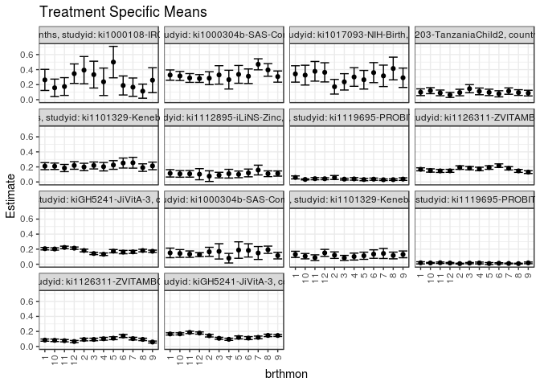

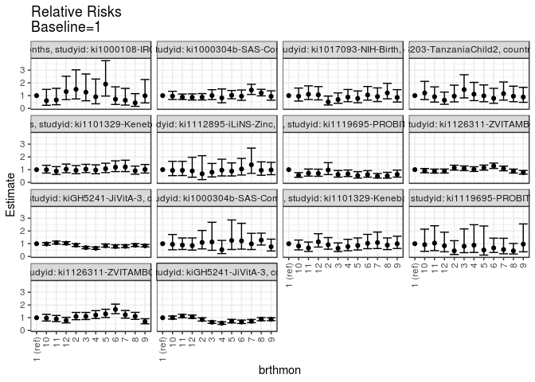

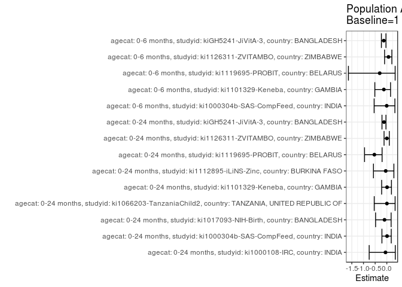

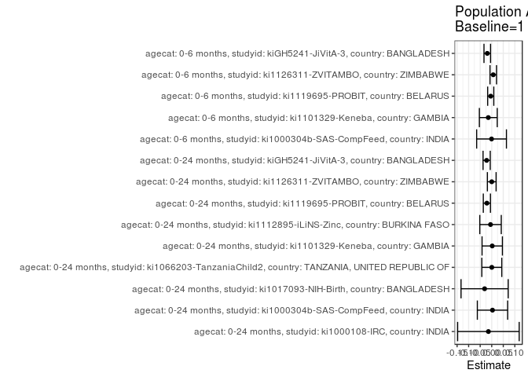

## Results Table

### Parameter: TSM

| agecat | studyid | country | intervention_level | baseline_level | estimate | ci_lower | ci_upper |
| --- | --- | --- | --- | --- | --- | --- | --- |
| 0-24 months | ki1000108-IRC | INDIA | 1 | NA | 0.2631579 | 0.1229792 | 0.4033366 |
| 0-24 months | ki1000108-IRC | INDIA | 2 | NA | 0.3928571 | 0.2117389 | 0.5739754 |
| 0-24 months | ki1000108-IRC | INDIA | 3 | NA | 0.3333333 | 0.1553045 | 0.5113621 |
| 0-24 months | ki1000108-IRC | INDIA | 4 | NA | 0.2380952 | 0.0557080 | 0.4204825 |
| 0-24 months | ki1000108-IRC | INDIA | 5 | NA | 0.5000000 | 0.2908119 | 0.7091881 |
| 0-24 months | ki1000108-IRC | INDIA | 6 | NA | 0.1891892 | 0.0628362 | 0.3155422 |
| 0-24 months | ki1000108-IRC | INDIA | 7 | NA | 0.1666667 | 0.0447787 | 0.2885546 |
| 0-24 months | ki1000108-IRC | INDIA | 8 | NA | 0.1136364 | 0.0197469 | 0.2075258 |
| 0-24 months | ki1000108-IRC | INDIA | 9 | NA | 0.2592593 | 0.0937597 | 0.4247588 |
| 0-24 months | ki1000108-IRC | INDIA | 10 | NA | 0.1578947 | 0.0418158 | 0.2739737 |
| 0-24 months | ki1000108-IRC | INDIA | 11 | NA | 0.1750000 | 0.0571053 | 0.2928947 |
| 0-24 months | ki1000108-IRC | INDIA | 12 | NA | 0.3461538 | 0.2166898 | 0.4756179 |
| 0-24 months | ki1000304b-SAS-CompFeed | INDIA | 1 | NA | 0.3274336 | 0.2590419 | 0.3958253 |
| 0-24 months | ki1000304b-SAS-CompFeed | INDIA | 2 | NA | 0.2857143 | 0.1998973 | 0.3715313 |
| 0-24 months | ki1000304b-SAS-CompFeed | INDIA | 3 | NA | 0.3292683 | 0.2067976 | 0.4517390 |
| 0-24 months | ki1000304b-SAS-CompFeed | INDIA | 4 | NA | 0.2666667 | 0.1419314 | 0.3914019 |
| 0-24 months | ki1000304b-SAS-CompFeed | INDIA | 5 | NA | 0.3366337 | 0.2186540 | 0.4546133 |
| 0-24 months | ki1000304b-SAS-CompFeed | INDIA | 6 | NA | 0.3119266 | 0.2149766 | 0.4088766 |
| 0-24 months | ki1000304b-SAS-CompFeed | INDIA | 7 | NA | 0.4705882 | 0.3972341 | 0.5439424 |
| 0-24 months | ki1000304b-SAS-CompFeed | INDIA | 8 | NA | 0.3956044 | 0.3114544 | 0.4797544 |
| 0-24 months | ki1000304b-SAS-CompFeed | INDIA | 9 | NA | 0.3072917 | 0.2329668 | 0.3816165 |
| 0-24 months | ki1000304b-SAS-CompFeed | INDIA | 10 | NA | 0.3154762 | 0.2553351 | 0.3756172 |
| 0-24 months | ki1000304b-SAS-CompFeed | INDIA | 11 | NA | 0.2887324 | 0.2303684 | 0.3470964 |
| 0-24 months | ki1000304b-SAS-CompFeed | INDIA | 12 | NA | 0.2816901 | 0.2298652 | 0.3335150 |
| 0-24 months | ki1017093-NIH-Birth | BANGLADESH | 1 | NA | 0.3424658 | 0.2335226 | 0.4514089 |
| 0-24 months | ki1017093-NIH-Birth | BANGLADESH | 2 | NA | 0.1724138 | 0.0751229 | 0.2697047 |
| 0-24 months | ki1017093-NIH-Birth | BANGLADESH | 3 | NA | 0.2372881 | 0.1286491 | 0.3459272 |
| 0-24 months | ki1017093-NIH-Birth | BANGLADESH | 4 | NA | 0.3018868 | 0.1781951 | 0.4255785 |
| 0-24 months | ki1017093-NIH-Birth | BANGLADESH | 5 | NA | 0.2653061 | 0.1415911 | 0.3890211 |
| 0-24 months | ki1017093-NIH-Birth | BANGLADESH | 6 | NA | 0.3600000 | 0.2268473 | 0.4931527 |

[output cut: 138 more lines]

### Parameter: E(Y)

| agecat | studyid | country | intervention_level | baseline_level | estimate | ci_lower | ci_upper |
| --- | --- | --- | --- | --- | --- | --- | --- |
| 0-24 months | ki1000108-IRC | INDIA | NA | NA | 0.2487805 | 0.2068840 | 0.2906770 |
| 0-24 months | ki1000304b-SAS-CompFeed | INDIA | NA | NA | 0.3307241 | 0.3024794 | 0.3589688 |
| 0-24 months | ki1017093-NIH-Birth | BANGLADESH | NA | NA | 0.3116057 | 0.2753823 | 0.3478292 |
| 0-24 months | ki1066203-TanzaniaChild2 | TANZANIA, UNITED REPUBLIC OF | NA | NA | 0.0997496 | 0.0877482 | 0.1117510 |
| 0-24 months | ki1101329-Keneba | GAMBIA | NA | NA | 0.2123499 | 0.1975010 | 0.2271989 |
| 0-24 months | ki1112895-iLiNS-Zinc | BURKINA FASO | NA | NA | 0.1093415 | 0.0900773 | 0.1286057 |
| 0-24 months | ki1119695-PROBIT | BELARUS | NA | NA | 0.0394153 | 0.0310085 | 0.0478221 |
| 0-24 months | ki1126311-ZVITAMBO | ZIMBABWE | NA | NA | 0.1681114 | 0.1619329 | 0.1742900 |
| 0-24 months | kiGH5241-JiVitA-3 | BANGLADESH | NA | NA | 0.1844493 | 0.1788538 | 0.1900447 |
| 0-6 months | ki1000304b-SAS-CompFeed | INDIA | NA | NA | 0.1496732 | 0.1307572 | 0.1685893 |
| 0-6 months | ki1101329-Keneba | GAMBIA | NA | NA | 0.1164300 | 0.1037657 | 0.1290943 |
| 0-6 months | ki1119695-PROBIT | BELARUS | NA | NA | 0.0142071 | 0.0107237 | 0.0176904 |
| 0-6 months | ki1126311-ZVITAMBO | ZIMBABWE | NA | NA | 0.0912001 | 0.0864407 | 0.0959595 |
| 0-6 months | kiGH5241-JiVitA-3 | BANGLADESH | NA | NA | 0.1473804 | 0.1423344 | 0.1524264 |

### Parameter: RR

| agecat | studyid | country | intervention_level | baseline_level | estimate | ci_lower | ci_upper |
| --- | --- | --- | --- | --- | --- | --- | --- |
| 0-24 months | ki1000108-IRC | INDIA | 1 | 1 | 1.0000000 | 1.0000000 | 1.0000000 |
| 0-24 months | ki1000108-IRC | INDIA | 2 | 1 | 1.4928571 | 0.7380162 | 3.0197472 |
| 0-24 months | ki1000108-IRC | INDIA | 3 | 1 | 1.2666667 | 0.5957531 | 2.6931364 |
| 0-24 months | ki1000108-IRC | INDIA | 4 | 1 | 0.9047619 | 0.3558975 | 2.3000840 |
| 0-24 months | ki1000108-IRC | INDIA | 5 | 1 | 1.9000000 | 0.9651389 | 3.7403943 |
| 0-24 months | ki1000108-IRC | INDIA | 6 | 1 | 0.7189189 | 0.3059649 | 1.6892280 |
| 0-24 months | ki1000108-IRC | INDIA | 7 | 1 | 0.6333333 | 0.2562718 | 1.5651783 |
| 0-24 months | ki1000108-IRC | INDIA | 8 | 1 | 0.4318182 | 0.1615717 | 1.1540814 |
| 0-24 months | ki1000108-IRC | INDIA | 9 | 1 | 0.9851852 | 0.4289835 | 2.2625340 |
| 0-24 months | ki1000108-IRC | INDIA | 10 | 1 | 0.6000000 | 0.2420309 | 1.4874132 |
| 0-24 months | ki1000108-IRC | INDIA | 11 | 1 | 0.6650000 | 0.2817309 | 1.5696718 |
| 0-24 months | ki1000108-IRC | INDIA | 12 | 1 | 1.3153846 | 0.6860957 | 2.5218593 |
| 0-24 months | ki1000304b-SAS-CompFeed | INDIA | 1 | 1 | 1.0000000 | 1.0000000 | 1.0000000 |
| 0-24 months | ki1000304b-SAS-CompFeed | INDIA | 2 | 1 | 0.8725869 | 0.6578014 | 1.1575042 |
| 0-24 months | ki1000304b-SAS-CompFeed | INDIA | 3 | 1 | 1.0056032 | 0.6911970 | 1.4630239 |
| 0-24 months | ki1000304b-SAS-CompFeed | INDIA | 4 | 1 | 0.8144144 | 0.4363099 | 1.5201828 |
| 0-24 months | ki1000304b-SAS-CompFeed | INDIA | 5 | 1 | 1.0280974 | 0.7536315 | 1.4025213 |
| 0-24 months | ki1000304b-SAS-CompFeed | INDIA | 6 | 1 | 0.9526407 | 0.6313796 | 1.4373672 |
| 0-24 months | ki1000304b-SAS-CompFeed | INDIA | 7 | 1 | 1.4372019 | 1.0931353 | 1.8895642 |
| 0-24 months | ki1000304b-SAS-CompFeed | INDIA | 8 | 1 | 1.2081972 | 0.9780004 | 1.4925766 |
| 0-24 months | ki1000304b-SAS-CompFeed | INDIA | 9 | 1 | 0.9384854 | 0.6394321 | 1.3774016 |
| 0-24 months | ki1000304b-SAS-CompFeed | INDIA | 10 | 1 | 0.9634813 | 0.6936680 | 1.3382430 |
| 0-24 months | ki1000304b-SAS-CompFeed | INDIA | 11 | 1 | 0.8818043 | 0.6924148 | 1.1229958 |
| 0-24 months | ki1000304b-SAS-CompFeed | INDIA | 12 | 1 | 0.8602969 | 0.6513979 | 1.1361884 |
| 0-24 months | ki1017093-NIH-Birth | BANGLADESH | 1 | 1 | 1.0000000 | 1.0000000 | 1.0000000 |
| 0-24 months | ki1017093-NIH-Birth | BANGLADESH | 2 | 1 | 0.5034483 | 0.2634076 | 0.9622354 |
| 0-24 months | ki1017093-NIH-Birth | BANGLADESH | 3 | 1 | 0.6928814 | 0.3967694 | 1.2099839 |
| 0-24 months | ki1017093-NIH-Birth | BANGLADESH | 4 | 1 | 0.8815094 | 0.5247448 | 1.4808320 |
| 0-24 months | ki1017093-NIH-Birth | BANGLADESH | 5 | 1 | 0.7746939 | 0.4405325 | 1.3623300 |
| 0-24 months | ki1017093-NIH-Birth | BANGLADESH | 6 | 1 | 1.0512000 | 0.6453779 | 1.7122084 |

[output cut: 138 more lines]

### Parameter: PAR

| agecat | studyid | country | intervention_level | baseline_level | estimate | ci_lower | ci_upper |
| --- | --- | --- | --- | --- | --- | --- | --- |
| 0-24 months | ki1000108-IRC | INDIA | 1 | NA | -0.0143774 | -0.1476551 | 0.1189002 |
| 0-24 months | ki1000304b-SAS-CompFeed | INDIA | 1 | NA | 0.0032904 | -0.0623284 | 0.0689093 |
| 0-24 months | ki1017093-NIH-Birth | BANGLADESH | 1 | NA | -0.0308600 | -0.1329672 | 0.0712471 |
| 0-24 months | ki1066203-TanzaniaChild2 | TANZANIA, UNITED REPUBLIC OF | 1 | NA | 0.0003344 | -0.0428972 | 0.0435659 |
| 0-24 months | ki1101329-Keneba | GAMBIA | 1 | NA | 0.0021804 | -0.0419238 | 0.0462846 |
| 0-24 months | ki1112895-iLiNS-Zinc | BURKINA FASO | 1 | NA | -0.0052096 | -0.0517005 | 0.0412813 |
| 0-24 months | ki1119695-PROBIT | BELARUS | 1 | NA | -0.0210136 | -0.0364969 | -0.0055302 |
| 0-24 months | ki1126311-ZVITAMBO | ZIMBABWE | 1 | NA | 0.0000997 | -0.0187644 | 0.0189638 |
| 0-24 months | kiGH5241-JiVitA-3 | BANGLADESH | 1 | NA | -0.0220125 | -0.0375469 | -0.0064781 |
| 0-6 months | ki1000304b-SAS-CompFeed | INDIA | 1 | NA | -0.0007693 | -0.0652700 | 0.0637315 |
| 0-6 months | ki1101329-Keneba | GAMBIA | 1 | NA | -0.0148441 | -0.0535343 | 0.0238461 |
| 0-6 months | ki1119695-PROBIT | BELARUS | 1 | NA | -0.0043295 | -0.0175771 | 0.0089181 |
| 0-6 months | ki1126311-ZVITAMBO | ZIMBABWE | 1 | NA | 0.0066413 | -0.0074656 | 0.0207482 |
| 0-6 months | kiGH5241-JiVitA-3 | BANGLADESH | 1 | NA | -0.0192862 | -0.0335425 | -0.0050299 |

### Parameter: PAF

| agecat | studyid | country | intervention_level | baseline_level | estimate | ci_lower | ci_upper |
| --- | --- | --- | --- | --- | --- | --- | --- |
| 0-24 months | ki1000108-IRC | INDIA | 1 | NA | -0.0577915 | -0.7552536 | 0.3625292 |
| 0-24 months | ki1000304b-SAS-CompFeed | INDIA | 1 | NA | 0.0099492 | -0.2096216 | 0.1896635 |
| 0-24 months | ki1017093-NIH-Birth | BANGLADESH | 1 | NA | -0.0990355 | -0.4808036 | 0.1843084 |
| 0-24 months | ki1066203-TanzaniaChild2 | TANZANIA, UNITED REPUBLIC OF | 1 | NA | 0.0033522 | -0.5395662 | 0.3548138 |
| 0-24 months | ki1101329-Keneba | GAMBIA | 1 | NA | 0.0102681 | -0.2208276 | 0.1976186 |
| 0-24 months | ki1112895-iLiNS-Zinc | BURKINA FASO | 1 | NA | -0.0476451 | -0.5731823 | 0.3023312 |
| 0-24 months | ki1119695-PROBIT | BELARUS | 1 | NA | -0.5331325 | -0.9541875 | -0.2027993 |
| 0-24 months | ki1126311-ZVITAMBO | ZIMBABWE | 1 | NA | 0.0005929 | -0.1181610 | 0.1067346 |
| 0-24 months | kiGH5241-JiVitA-3 | BANGLADESH | 1 | NA | -0.1193419 | -0.2070404 | -0.0380152 |
| 0-6 months | ki1000304b-SAS-CompFeed | INDIA | 1 | NA | -0.0051397 | -0.5433859 | 0.3453965 |
| 0-6 months | ki1101329-Keneba | GAMBIA | 1 | NA | -0.1274938 | -0.5136818 | 0.1601654 |
| 0-6 months | ki1119695-PROBIT | BELARUS | 1 | NA | -0.3047439 | -1.6446168 | 0.3562936 |
| 0-6 months | ki1126311-ZVITAMBO | ZIMBABWE | 1 | NA | 0.0728211 | -0.0954659 | 0.2152556 |
| 0-6 months | kiGH5241-JiVitA-3 | BANGLADESH | 1 | NA | -0.1308602 | -0.2321437 | -0.0379023 |